# Lab5-demo

2026-05-12

This full data set includes more possible predictors than the text alone, but for this model we will only use the text variable

```r
urlfile ="https://raw.githubusercontent.com/MaRo406/EDS-231-text-sentiment/main/data/climbing_reports_model_dat.csv"
incidents_df<-readr::read_csv(url(urlfile))
glimpse(incidents_df)
```

```
## Rows: 2,770
## Columns: 5
## $ ID                 <chr> "1", "2", "3", "4", "5", "6", "7", "8", "9", "10", …
## $ `Accident Title`   <chr> "Failure of Rappel Setup (Protection Pulled Out), I…
## $ `Publication Year` <dbl> 1990, 1990, 1990, 1990, 1990, 1990, 1990, 1990, 199…
## $ Text               <chr> "Colorado, Rocky Mountain National Park\nOn May 7, …
## $ Deadly             <dbl> NA, NA, NA, NA, 1, 1, NA, NA, NA, NA, NA, 1, 1, NA,…
```

```r
# How many incidents are marked as deadly?

incidents_df |>
  count(Deadly, name = "n")
```

```
## # A tibble: 2 × 2
##   Deadly     n
##    <dbl> <int>
## 1      1   563
## 2     NA  2207
```

Now we’ll split our data into training and test portions

```r
set.seed(321)
incidents2class <- incidents_df |>
  mutate(deadly = factor(if_else(
    is.na(Deadly),
    "non-deadly", "deadly"
  )))

#split our data
incidents_split <- initial_split(incidents2class, prop = 0.8, strata = deadly)

incidents_train <- training(incidents_split)
incidents_test <- testing(incidents_split)
```

We use recipe() to specify the predictor and outcome variables and the data.

```r
incidents_rec <- recipe(deadly ~ Text, data = incidents_train)
```

Next we add some familiar pre-processing steps on our Text variable: tokenize to word level, filter to the most common words, and calculate tf-idf.

```r
recipe <- incidents_rec |>
  step_tokenize(Text) |>
  step_tokenfilter(Text, max_tokens = 1000) |>
  step_tfidf(Text)

recipe
```

```
## ── Recipe ──────────────────────────────────────────────────────────────────────
```

```
## ── Inputs
```

```
## Number of variables by role
```

```
## outcome:   1
## predictor: 1
```

```
## ── Operations
```

```
## • Tokenization for: Text
```

```
## • Text filtering for: Text
```

```
## • Term frequency-inverse document frequency with: Text
```

> **Python parallel:** This three-step recipe maps almost directly onto a single sklearn object: `TfidfVectorizer(max_features=1000)`.

```r
nb_spec <- naive_Bayes() %>%
  set_mode("classification") %>% #set modeling context
  set_engine("naivebayes") #method for fitting model
```

Time for model evaluation. We’ll do a standard resampling process to evaluate our naive Bayes model. Here we create 10-fold cross-validation sets, and use them to estimate performance. `vfold_cv` let’s us do this.

```r
set.seed(123)
incidents_folds <- vfold_cv(incidents_train)

incidents_folds
```

```
## #  10-fold cross-validation
## # A tibble: 10 × 2
##    splits             id
##    <list>             <chr>
##  1 <split [1993/222]> Fold01
##  2 <split [1993/222]> Fold02
##  3 <split [1993/222]> Fold03
##  4 <split [1993/222]> Fold04
##  5 <split [1993/222]> Fold05
##  6 <split [1994/221]> Fold06
##  7 <split [1994/221]> Fold07
##  8 <split [1994/221]> Fold08
##  9 <split [1994/221]> Fold09
## 10 <split [1994/221]> Fold10
```

Create a tidymodels workflow to combine the modeling components

> **Python parallel:** A `workflow()` is the tidymodels equivalent of `sklearn.pipeline.Pipeline`. Both bundle preprocessing and a model estimator into a single object that can be fit, cross-validated, and used for prediction in one call.

```r
nb_wf <- workflow() |>
  add_recipe(recipe) |>
  add_model(nb_spec)
```

To estimate its performance, we fit the model to each of the resampled folds, and then evaluate on the heldout part of each resampled fold.

```r
nb_rs <- tune::fit_resamples(
  nb_wf,
  incidents_folds,
  control = control_resamples(save_pred=TRUE)

)
```

> **Python parallel:** `fit_resamples()` is doing what `cross_validate(pipeline, X, y, cv=kfold, scoring=['accuracy','roc_auc'], return_estimator=True)` does in sklearn — fitting the full pipeline (preprocessing + model) on each training fold and scoring on the held-out fold.

Extract the relevant information using collect_metrics() and collect_predictions() and examine the performance metrics.

```r
nb_rs_metrics <- collect_metrics(nb_rs)
nb_rs_predictions <- collect_predictions(nb_rs)
nb_rs_metrics
```

```
## # A tibble: 3 × 6
##   .metric     .estimator  mean     n std_err .config
##   <chr>       <chr>      <dbl> <int>   <dbl> <chr>
## 1 accuracy    binary     0.802    10 0.00986 pre0_mod0_post0
## 2 brier_class binary     0.198    10 0.00987 pre0_mod0_post0
## 3 roc_auc     binary     0.733    10 0.0114  pre0_mod0_post0
```

We’ll use two performance metrics: accuracy and ROC AUC. Accuracy is the proportion of the data that is predicted correctly. The ROC curve plots the true positive rate against the false positive rate; AUC closer to 1 indicates a better-performing model, while AUC closer to 0.5 indicates a model that does no better than random guessing.

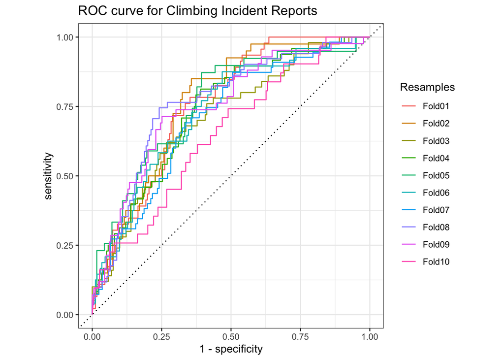

```r
nb_rs_predictions %>%
  group_by(id) %>%
  roc_curve(truth = deadly, .pred_deadly) %>%
  autoplot() +
  labs(
    color = "Resamples",
    title = "ROC curve for Climbing Incident Reports"
  )
```

Another model method involves the confusion matrix. A confusion matrix tabulates a model’s false positives and false negatives for each class.

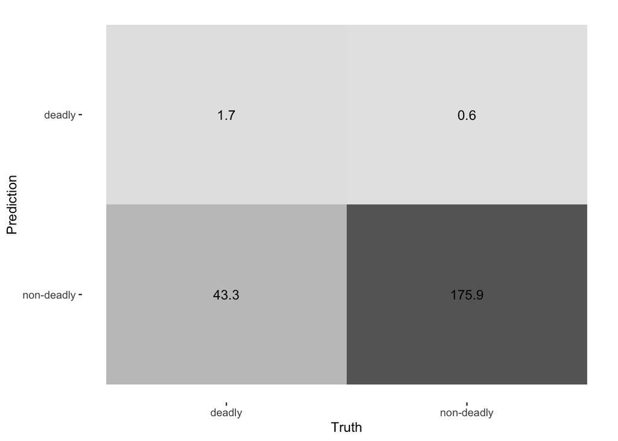

```r
conf_mat_resampled(nb_rs, tidy = FALSE) %>% #compute matrix for each fold then average
  autoplot(type = "heatmap")
```

Hmm, let’s try a different model.

Lasso classification uses regularization on regression to produce a simpler, more generalizable model. It learns how much of a penalty to apply to features, reducing the high-dimensional space of tokens — sometimes shrinking coefficients all the way to 0, effectively removing those features from the model entirely.

The penalty is a hyperparameter we need to choose. Rather than setting it manually, we estimate its best value by fitting models across 30 candidate penalty values on our resampled data and comparing performance.

```r
tune_spec <- logistic_reg(penalty = tune(), mixture = 1) %>%
  set_mode("classification") %>%
  set_engine("glmnet")

tune_spec
```

```
## Logistic Regression Model Specification (classification)
##
## Main Arguments:
##   penalty = tune()
##   mixture = 1
##
## Computational engine: glmnet
```

```r
tune_spec <- logistic_reg(penalty=tune(), mixture = 1) |>
  set_mode("classification") |>
  set_engine("glmnet")

tune_spec
```

```
## Logistic Regression Model Specification (classification)
##
## Main Arguments:
##   penalty = tune()
##   mixture = 1
##
## Computational engine: glmnet
```

Here we use grid_regular() to create 30 possible values for the regularization penalty. Then tune_grid() fits a model at each of those values.

```r
lambda_grid <- grid_regular(penalty(), levels = 30)

lambda_grid
```

```
## # A tibble: 30 × 1
##     penalty
##       <dbl>
##  1 1   e-10
##  2 2.21e-10
##  3 4.89e-10
##  4 1.08e- 9
##  5 2.40e- 9
##  6 5.30e- 9
##  7 1.17e- 8
##  8 2.59e- 8
##  9 5.74e- 8
## 10 1.27e- 7
## # ℹ 20 more rows
```

> **Python parallel:** `grid_regular(penalty(), levels = 30)` + `tune_grid()` is akin to using `GridSearchCV().

```r
lasso_wf <- workflow() %>%
  add_recipe(recipe) %>%
  add_model(tune_spec)

set.seed(2023)
tune_rs <- tune_grid(
  lasso_wf,
  incidents_folds,
  grid = lambda_grid,
  control = control_resamples(save_pred = T)

)
```

```r
collect_metrics(tune_rs)
```

```
## # A tibble: 90 × 7
##     penalty .metric     .estimator  mean     n std_err .config
##       <dbl> <chr>       <chr>      <dbl> <int>   <dbl> <chr>
##  1 1   e-10 accuracy    binary     0.886    10 0.00502 pre0_mod01_post0
##  2 1   e-10 brier_class binary     0.102    10 0.00364 pre0_mod01_post0
##  3 1   e-10 roc_auc     binary     0.919    10 0.00554 pre0_mod01_post0
##  4 2.21e-10 accuracy    binary     0.886    10 0.00502 pre0_mod02_post0
##  5 2.21e-10 brier_class binary     0.102    10 0.00364 pre0_mod02_post0
##  6 2.21e-10 roc_auc     binary     0.919    10 0.00554 pre0_mod02_post0
##  7 4.89e-10 accuracy    binary     0.886    10 0.00502 pre0_mod03_post0
##  8 4.89e-10 brier_class binary     0.102    10 0.00364 pre0_mod03_post0
##  9 4.89e-10 roc_auc     binary     0.919    10 0.00554 pre0_mod03_post0
## 10 1.08e- 9 accuracy    binary     0.886    10 0.00502 pre0_mod04_post0
## # ℹ 80 more rows
```

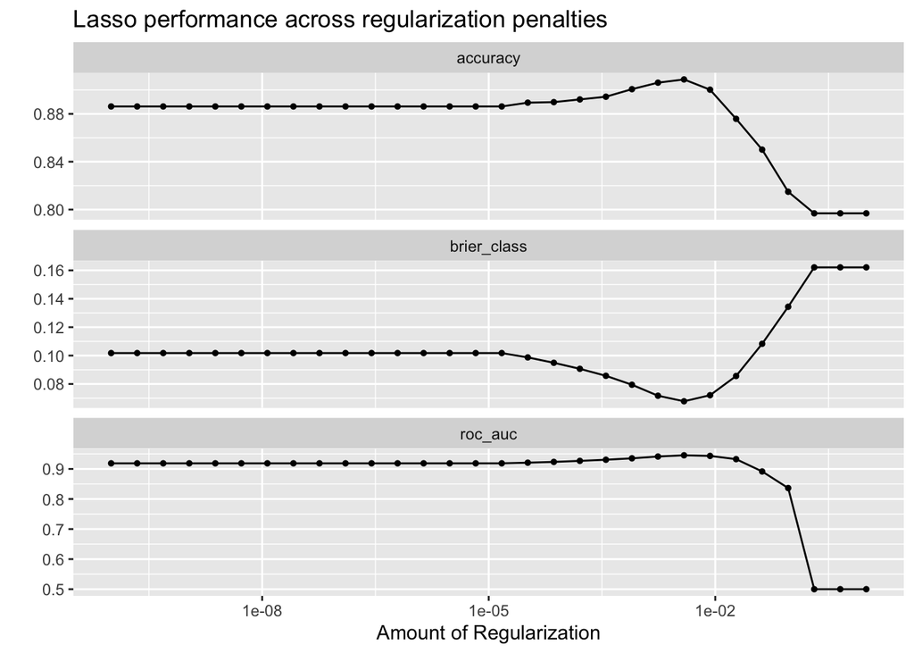

```r
autoplot(tune_rs) +
  labs(
    title = "Lasso performance across regularization penalties"
  )
```

```r
tune_rs %>%
  show_best(metric = "roc_auc")
```

```
## # A tibble: 5 × 7
##    penalty .metric .estimator  mean     n std_err .config
##      <dbl> <chr>   <chr>      <dbl> <int>   <dbl> <chr>
## 1 0.00386  roc_auc binary     0.945    10 0.00489 pre0_mod23_post0
## 2 0.00853  roc_auc binary     0.943    10 0.00498 pre0_mod24_post0
## 3 0.00174  roc_auc binary     0.941    10 0.00491 pre0_mod22_post0
## 4 0.000788 roc_auc binary     0.935    10 0.00482 pre0_mod21_post0
## 5 0.0189   roc_auc binary     0.933    10 0.00609 pre0_mod25_post0
```

```r
tune_rs %>%
  show_best(metric = "accuracy")
```

```
## # A tibble: 5 × 7
##    penalty .metric  .estimator  mean     n std_err .config
##      <dbl> <chr>    <chr>      <dbl> <int>   <dbl> <chr>
## 1 0.00386  accuracy binary     0.909    10 0.00471 pre0_mod23_post0
## 2 0.00174  accuracy binary     0.906    10 0.00492 pre0_mod22_post0
## 3 0.000788 accuracy binary     0.901    10 0.00492 pre0_mod21_post0
## 4 0.00853  accuracy binary     0.900    10 0.00557 pre0_mod24_post0
## 5 0.000356 accuracy binary     0.894    10 0.00566 pre0_mod20_post0
```

```r
chosen_acc <- tune_rs %>%
  select_by_one_std_err(metric = "accuracy", -penalty)
```

Next, let’s finalize our workflow with this particular regularization penalty. This is the regularization penalty that our tuning results indicate give us the best model.

```r
final_lasso <- finalize_workflow(lasso_wf, chosen_acc
                                 )

final_lasso
```

```
## ══ Workflow ════════════════════════════════════════════════════════════════════
## Preprocessor: Recipe
## Model: logistic_reg()
##
## ── Preprocessor ────────────────────────────────────────────────────────────────
## 3 Recipe Steps
##
## • step_tokenize()
## • step_tokenfilter()
## • step_tfidf()
##
## ── Model ───────────────────────────────────────────────────────────────────────
## Logistic Regression Model Specification (classification)
##
## Main Arguments:
##   penalty = 0.00385662042116347
##   mixture = 1
##
## Computational engine: glmnet
```

The penalty argument value now reflects our tuning result. Now we fit to our training data.

```r
fitted_lasso <- fit(final_lasso, incidents_train)

fitted_lasso
```

```
## ══ Workflow [trained] ══════════════════════════════════════════════════════════
## Preprocessor: Recipe
## Model: logistic_reg()
##
## ── Preprocessor ────────────────────────────────────────────────────────────────
## 3 Recipe Steps
##
## • step_tokenize()
## • step_tokenfilter()
## • step_tfidf()
##
## ── Model ───────────────────────────────────────────────────────────────────────
##
## Call:  glmnet::glmnet(x = maybe_matrix(x), y = y, family = "binomial",      alpha = ~1)
##
```

[output cut: 50 more lines]

First let’s look at the words associated with an accident being non-deadly.

```r
fitted_lasso |>
  extract_fit_parsnip() |>
  tidy() |>
  arrange(-estimate)
```

```
## # A tibble: 1,001 × 3
##    term                  estimate penalty
##    <chr>                    <dbl>   <dbl>
##  1 tfidf_Text_analysis      136.  0.00386
##  2 tfidf_Text_hospital       91.1 0.00386
##  3 tfidf_Text_injury         82.9 0.00386
##  4 tfidf_Text_condition      76.1 0.00386
##  5 tfidf_Text_treatment      70.7 0.00386
##  6 tfidf_Text_me             67.3 0.00386
##  7 tfidf_Text_assessment     65.4 0.00386
##  8 tfidf_Text_fractured      63.5 0.00386
##  9 tfidf_Text_pain           62.5 0.00386
## 10 tfidf_Text_case           59.4 0.00386
## # ℹ 991 more rows
```

```r
fitted_lasso|>
  extract_fit_parsnip() |>
  tidy() |>
  arrange(-estimate)
```

```
## # A tibble: 1,001 × 3
##    term                  estimate penalty
##    <chr>                    <dbl>   <dbl>
##  1 tfidf_Text_analysis      136.  0.00386
##  2 tfidf_Text_hospital       91.1 0.00386
##  3 tfidf_Text_injury         82.9 0.00386
##  4 tfidf_Text_condition      76.1 0.00386
##  5 tfidf_Text_treatment      70.7 0.00386
##  6 tfidf_Text_me             67.3 0.00386
##  7 tfidf_Text_assessment     65.4 0.00386
##  8 tfidf_Text_fractured      63.5 0.00386
##  9 tfidf_Text_pain           62.5 0.00386
## 10 tfidf_Text_case           59.4 0.00386
## # ℹ 991 more rows
```

Finally, let’s fit to the test data and see how we did.

```r
last_fit(final_lasso, incidents_split) %>%
  collect_metrics()
```

```
## # A tibble: 3 × 4
##   .metric     .estimator .estimate .config
##   <chr>       <chr>          <dbl> <chr>
## 1 accuracy    binary        0.919  pre0_mod0_post0
## 2 roc_auc     binary        0.951  pre0_mod0_post0
## 3 brier_class binary        0.0620 pre0_mod0_post0
```

## Lab 5 Assignment: Due May 19 at 11:59pm

### Language & Tools

You may complete this assignment **in R or Python** — your choice. If you work in Python, submit a `.ipynb` or `.py` script along with the knit product instead of the `.Rmd`.

### AI Use

You are permitted to use Claude (or another LLM) **more liberally than in previous labs** for this assignment, including for help writing or debugging code you haven’t used before. However:

- **Every AI-assisted code block must include a comment** identifying it as AI-assisted and briefly describing what you asked for (e.g., `# Claude: asked for help adapting the tune_grid workflow to a random forest spec`).
- **All written interpretation must be your own.** Do not use AI to generate your written responses to the questions below — these are graded primarily on your reasoning, not on the code that produced the results.

### Grading

Grading for this lab weights **interpretation and documentation more heavily than code correctness**. A working model with shallow interpretation will score lower than a model with minor implementation issues but clear, thoughtful commentary on what the results mean.

### Tasks

**1.** Select a third classification algorithm beyond Naive Bayes and Lasso (e.g., random forest, k-nearest neighbors, support vector machine, decision tree). Report its cross-validated accuracy and ROC AUC.

**2.** Identify the key hyperparameter(s) for your chosen algorithm. Tune at least one hyperparameter using cross-validation and select a final value. Briefly explain in plain language what the hyperparameter controls and why tuning it matters.

**3.** Fit your final tuned model and evaluate it on the test set. Compare its accuracy and ROC AUC to the Naive Bayes and Lasso models from the demo. Which model performs best, and why do you think that is?

**4.** Examine the confusion matrix for your tuned model. What does the confusion matrix tell you about how the model is handling the minority class? Is overall accuracy a good summary metric here? What would you prioritize — minimizing false negatives (missed fatalities) or false positives (false alarms) — and why?